# **TREE**

## Pengertian Tree

Tree adalah struktur data non-linear yang digunakan untuk menyimpan data dalam bentuk **hubungan bertingkat atau hierarki**.

Tree disebut struktur data hierarki karena hubungan antar datanya menyerupai:

- pohon keluarga,
- struktur organisasi,
- folder komputer,
- atau cabang pohon.

Dalam Tree:

- data disimpan dalam node,
- dan node-node tersebut saling terhubung membentuk cabang.

Berbeda dengan Linked List yang hanya memiliki hubungan satu jalur, Tree memiliki:

- parent,
- child,
- dan cabang yang bercabang ke banyak arah.

Tree merupakan salah satu struktur data paling penting dalam ilmu komputer karena digunakan hampir di semua sistem modern seperti:

- database,
- file system,
- compiler,
- artificial intelligence,
- machine learning,
- routing jaringan,
- dan search engine.

Contoh perusahaan yang menggunakan struktur Tree dalam sistem mereka:

- Google
- Microsoft
- Oracle

# Konsep Dasar Tree

Tree terdiri dari kumpulan node yang saling terhubung.

Hubungan utama pada Tree:

- parent (induk),
- child (anak).

# Ilustrasi Sederhana Tree

```
        A
       / \
      B   C
     / \
    D   E
```

Penjelasan:

- A adalah parent dari B dan C
- B adalah parent dari D dan E
- D dan E adalah child dari B

# Karakteristik Tree

## 1. Memiliki Root

Tree selalu memiliki node utama yang disebut:

> Root

## 2. Memiliki Parent dan Child

Setiap node dapat memiliki:

- parent,
- child.

## 3. Bersifat Hierarki

Data tersusun bertingkat.

## 4. Tidak Membentuk Siklus

Tree tidak boleh membentuk lingkaran (cycle).

## 5. Memiliki Cabang

Satu node dapat memiliki banyak child.

# Komponen-Komponen Tree

Tree memiliki banyak istilah penting yang wajib dipahami.

# 1. Root

Root adalah node paling atas dalam Tree.

Contoh:

```
A
```

Pada gambar sebelumnya:

- A adalah root.

Root tidak memiliki parent.

# 2. Node

Node adalah elemen penyimpan data pada Tree.

Contoh:

```
A, B, C, D, E
```

Semuanya disebut node.

# 3. Edge

Edge adalah garis penghubung antar node.

Contoh:

```
A --- B
```

# 4. Parent

Parent adalah node yang memiliki child.

Contoh:

```
A
|
B
```

A adalah parent dari B.

# 5. Child

Child adalah node turunan dari parent.

Contoh:

```
A
|
B
```

B adalah child dari A.

# 6. Sibling

Sibling adalah node yang memiliki parent sama.

Contoh:

```
    A
   / \
  B   C
```

B dan C adalah sibling.

# 7. Leaf Node

Leaf node adalah node yang tidak memiliki child.

Contoh:

```
D, E, C
```

# 8. Internal Node

Internal node adalah node yang memiliki child.

Contoh:

```
A, B
```

# 9. Subtree

Subtree adalah bagian kecil dari Tree.

Contoh:

```
    B
   / \
  D   E
```

Merupakan subtree dari Tree utama.

# 10. Height

Height adalah tinggi Tree.

Height dihitung dari:

- root,
- sampai leaf terdalam.

# 11. Depth

Depth adalah kedalaman suatu node.

# 12. Level

Level menunjukkan posisi node dalam Tree.

Contoh:

```
Level 0 : A
Level 1 : B, C
Level 2 : D, E
```

# Struktur Dasar Tree

Tree memiliki bentuk:

```
        Root
       /    \
    Child  Child
```

Tree dapat berkembang menjadi sangat besar dan kompleks.

# Jenis-Jenis Tree

Tree memiliki banyak jenis.

# 1. General Tree

General Tree adalah Tree dimana setiap node dapat memiliki jumlah child bebas.

Contoh:

```
       A
     / | \
    B  C  D
```

# 2. Binary Tree

Binary Tree adalah Tree dimana setiap node maksimal memiliki:

- 2 child.

Contoh:

```
      A
     / \
    B   C
```

# 3. Binary Search Tree (BST)

BST adalah Binary Tree dengan aturan:

- child kiri lebih kecil,
- child kanan lebih besar.

Contoh:

```
       50
      /  \
    30    70
```

# 4. AVL Tree

AVL Tree adalah BST yang seimbang.

Digunakan untuk menjaga performa searching tetap cepat.

# 5. Heap Tree

Heap digunakan pada:

- priority queue,
- scheduling,
- heap sort.

Jenis:

- Max Heap
- Min Heap

# 6. B-Tree

Digunakan pada:

- database,
- file system,
- indexing.

Contoh penggunaan:

- MySQL
- PostgreSQL

# 7. Trie Tree

Trie digunakan untuk:

- pencarian kata,
- autocomplete,
- dictionary.

Digunakan oleh:

- Google

# Binary Tree

# Pengertian Binary Tree

Binary Tree adalah Tree yang setiap node maksimal memiliki dua child:

1. left child,
2. right child.

# Contoh Binary Tree

```
       A
      / \
     B   C
    / \
   D   E
```

# Jenis Binary Tree

# 1. Full Binary Tree

Setiap node memiliki:

- 0 atau 2 child.

# 2. Complete Binary Tree

Semua level terisi penuh kecuali level terakhir.

# 3. Perfect Binary Tree

Semua node internal memiliki 2 child dan semua leaf sejajar.

# 4. Skewed Tree

Tree miring ke satu arah.

# Binary Search Tree (BST)

# Pengertian BST

BST adalah Binary Tree dengan aturan:

- kiri < parent
- kanan > parent

# Contoh BST

```
        50
       /  \
     30    70
    / \    / \
   20 40 60 80
```

# Keunggulan BST

BST mempercepat:

- searching,
- insertion,
- deletion.

# Kompleksitas BST

## Best Case

O(\log n)

## Worst Case

Jika tree tidak seimbang:

O(n)

# Traversal Pada Tree

Traversal adalah proses mengunjungi seluruh node pada Tree.

# Jenis Traversal

# 1. Preorder Traversal

Urutan:

1. Root
2. Left
3. Right

Contoh:

```
A B D E C
```

# 2. Inorder Traversal

Urutan:

1. Left
2. Root
3. Right

Contoh:

```
D B E A C
```

# 3. Postorder Traversal

Urutan:

1. Left
2. Right
3. Root

Contoh:

```
D E B C A
```

# 4. Level Order Traversal

Traversal berdasarkan level.

Contoh:

```
A B C D E
```

# Operasi Dasar Tree

# 1. Insertion

Menambahkan node baru.

# 2. Deletion

Menghapus node.

# 3. Searching

Mencari data dalam Tree.

# 4. Traversal

Menelusuri seluruh node.

# Kompleksitas Tree

| Operasi | Kompleksitas |
| --- | --- |
| Searching BST | O(\log n) |
| Insertion BST | O(\log n) |
| Deletion BST | O(\log n) |

# Perbedaan Tree dan Linked List

| Linked List | Tree |
| --- | --- |
| Linear | Hierarki |
| Satu jalur | Banyak cabang |
| Traversal satu arah | Traversal bercabang |
| Lebih sederhana | Lebih kompleks |

# Penerapan Tree Dalam Dunia Nyata

# 1. Struktur Folder Komputer

Folder dan subfolder membentuk Tree.

Contoh sistem operasi:

- Microsoft Windows
- Apple macOS

# 2. Database

B-Tree digunakan untuk indexing database.

# 3. Search Engine

Search engine menggunakan Tree untuk indexing data internet.

Contoh:

- Google

# 4. Artificial Intelligence

Decision Tree digunakan pada AI dan Machine Learning.

# Contoh Program Binary Tree Python

```
class Node:

    def __init__(self, data):

        self.data = data
        self.left = None
        self.right = None


root = Node(10)

root.left = Node(5)
root.right = Node(15)

print(root.data)
print(root.left.data)
print(root.right.data)
```

# Penjelasan Program

## 1. Class Node

```
self.left
self.right
```

Digunakan untuk child kiri dan kanan.

## 2. Root

```
root = Node(10)
```

Membuat root Tree.

## 3. Menambahkan Child

```
root.left = Node(5)
```

Menambahkan child kiri.

# Output Program

```
10
5
15
```

# Contoh Traversal Inorder Python

```
def inorder(node):

    if node:

        inorder(node.left)

        print(node.data)

        inorder(node.right)
```

# Kesimpulan

Tree adalah struktur data non-linear yang menyimpan data dalam bentuk hierarki menggunakan node dan cabang.

Tree sangat penting karena:

- cepat untuk searching,
- fleksibel,
- efisien,
- dan digunakan hampir di semua sistem komputer modern.

Tree memiliki banyak jenis seperti:

- Binary Tree,
- BST,
- AVL,
- Heap,
- B-Tree,
- dan Trie.

Karena kemampuannya dalam mengelola data bertingkat secara efisien, Tree menjadi salah satu struktur data paling penting dalam Struktur Data dan Algoritma.

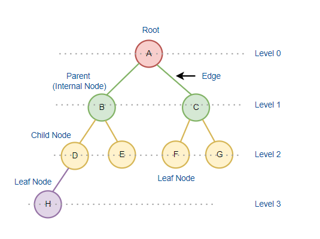

### **Contoh Code:**

```python
class Node:

    def __init__(self, data):
        self.data = data
        self.left = None
        self.right = None

root = Node(1)

root.left = Node(2)
root.right = Node(3)

print(root.data)
print(root.left.data)
print(root.right.data)
```

```
1
2
3
```

```python
class Node:
    def __init__(self, data):

        self.data = data
        self.left = None
        self.right = None

root = Node(1)

root.left = Node(2)
root.right = Node(3)

root.left.left = Node(4)
root.left.right = Node(5)

root.right.left = Node(6)
root.right.right = Node(7)

print("Root :", root.data)

print("Left Child :", root.left.data)
print("Right Child :", root.right.data)

print("Leaf :", root.left.left.data)
print("Leaf :", root.left.right.data)
print("Leaf :", root.right.left.data)
print("Leaf :", root.right.right.data)
```

```
Root : 1
Left Child : 2
Right Child : 3
Leaf : 4
Leaf : 5
Leaf : 6
Leaf : 7
```

```python
class Node:
    def __init__(self, data):
        self.data = data
        self.left = None
        self.right = None

def preorder(node):

    if node:
        print(node.data)

        preorder(node.left)
        preorder(node.right)

root = Node(1)
root.left = Node(2)
root.right = Node(3)
root.left.left = Node(4)
root.left.right = Node(5)

print("Preorder Traversal:")

preorder(root)
```

```
Preorder Traversal:
1
2
4
5
3
```

```python
class Node:
    def __init__(self, data):
        self.data = data
        self.left = None
        self.right = None

def inorder(node):
    if node:
        inorder(node.left)
        print(node.data)
        inorder(node.right)

root = Node(1)

root.left = Node(2)
root.right = Node(3)

root.left.left = Node(4)
root.left.right = Node(5)

print("Inorder Traversal:")

inorder(root)
```

```
Inorder Traversal:
4
2
5
1
3
```

```python
class Node:
    def __init__(self, data):
        self.data = data
        self.left = None
        self.right = None


def insert(root, data):
    if root is None:
        return Node(data)

    if data < root.data:
        root.left = insert(root.left, data)
    else:
        root.right = insert(root.right, data)
    return root

def inorder(root):

    if root:
        inorder(root.left)
        print(root.data)
        inorder(root.right)

root = None
root = insert(root, 50)
root = insert(root, 30)
root = insert(root, 70)
root = insert(root, 20)
root = insert(root, 40)

print("Inorder BST:")

inorder(root)
```

```
Inorder BST:
20
30
40
50
70
```

```python
class Node:
    def __init__(self, data):

        self.data = data
        self.left = None
        self.right = None

def search(root, key):

    if root is None:
        return False

    if root.data == key:
        return True

    if key < root.data:
        return search(root.left, key)
    return search(root.right, key)

root = Node(50)

root.left = Node(30)
root.right = Node(70)

root.left.left = Node(20)
root.left.right = Node(40)

if search(root, 40):
    print("Data ditemukan")
else:
    print("Data tidak ditemukan")
```

```
Data ditemukan
```

## ⬅ Kembali